# examples_0601

Let matrices $A$ and $B$ be defined below.

$$A = \begin{bmatrix}
3 & 6 & 1 & 2\\
3 & 6 & 5 & 4\\
1 & 0 & 0 & 0
\end{bmatrix}$$
$$B = \begin{bmatrix}
2 & 5 & 1 & 5 & 3\\
6 & 5 & 4 & 0 & 2\\
2 & 0 & 5 & 3 & 0\\
0 & 3 & 4 & 2 & 5
\end{bmatrix}$$

A third matrix, $C$, is equal to the [product](https://en.wikipedia.org/wiki/Matrix_multiplication) $AB$. A student set up a diagram to help find the product; they are missing a single element in $C$, element $c_{1,2}$.

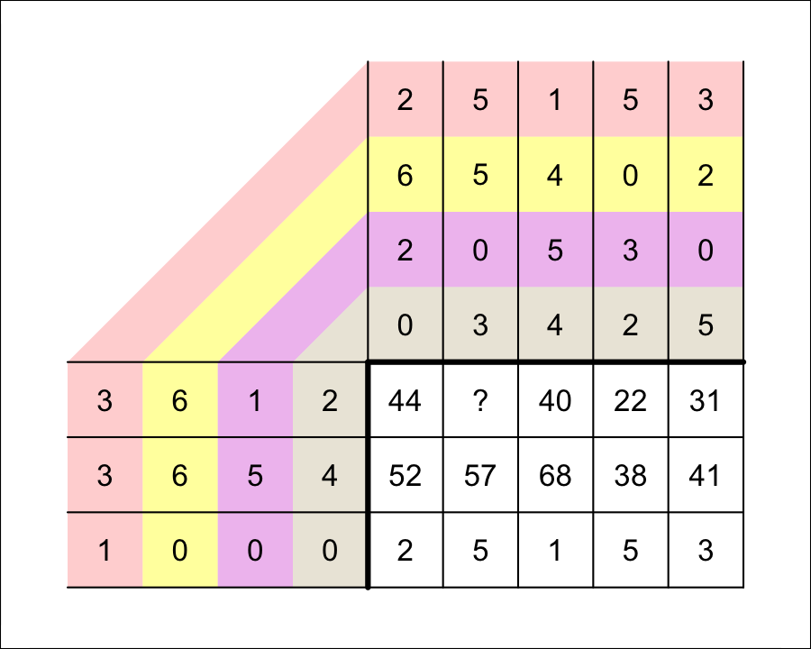

What is $c_{1,2}$?

To find $c_{1,2}$, you use row 1 from matrix $A$ and column 2 from matrix $B$.

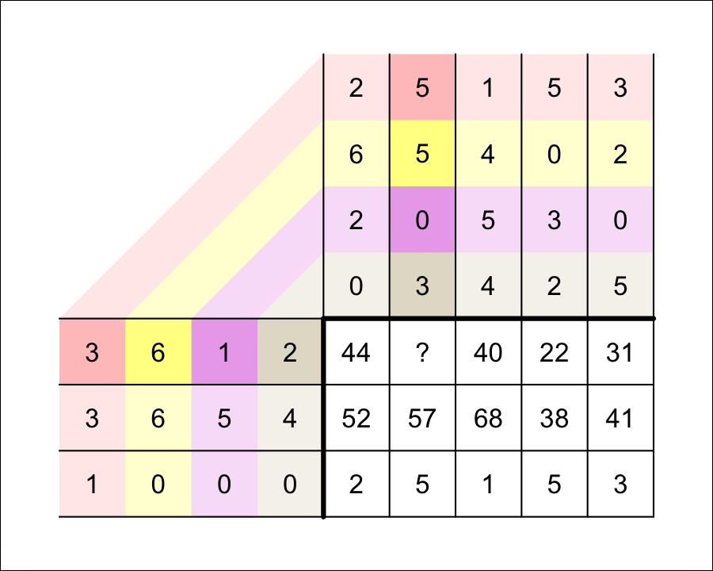

You multiply corresponding elements and sum those products.

$$c_{1,2}~=~( 3 \cdot 5 )+( 6 \cdot 5
)+( 1 \cdot 0 )+( 2 \cdot 3 )$$

$$c_{1,2}~=~15+30+0+6$$

$$c_{1,2}~=~51$$

Thus,

$$\begin{bmatrix}
3 & 6 & 1 & 2\\
3 & 6 & 5 & 4\\
1 & 0 & 0 & 0
\end{bmatrix} \cdot \begin{bmatrix}
2 & 5 & 1 & 5 & 3\\
6 & 5 & 4 & 0 & 2\\
2 & 0 & 5 & 3 & 0\\
0 & 3 & 4 & 2 & 5
\end{bmatrix} ~=~ \begin{bmatrix}
44 & 51 & 40 & 22 & 31\\
52 & 57 & 68 & 38 & 41\\
2 & 5 & 1 & 5 & 3
\end{bmatrix}$$

Let matrices $A$ and $B$ be defined below.

$$A = \begin{bmatrix}
2 & 3 & 2 & 0\\
2 & 5 & 5 & 2\\
6 & 2 & 0 & 6
\end{bmatrix}$$
$$B = \begin{bmatrix}
4 & 2 & 4 & 1 & 1\\
0 & 5 & 0 & 3 & 3\\
6 & 0 & 3 & 1 & 0\\
0 & 1 & 3 & 3 & 3
\end{bmatrix}$$

A third matrix, $C$, is equal to the [product](https://en.wikipedia.org/wiki/Matrix_multiplication) $AB$. A student set up a diagram to help find the product; they are missing a single element in $C$, element $c_{1,1}$.

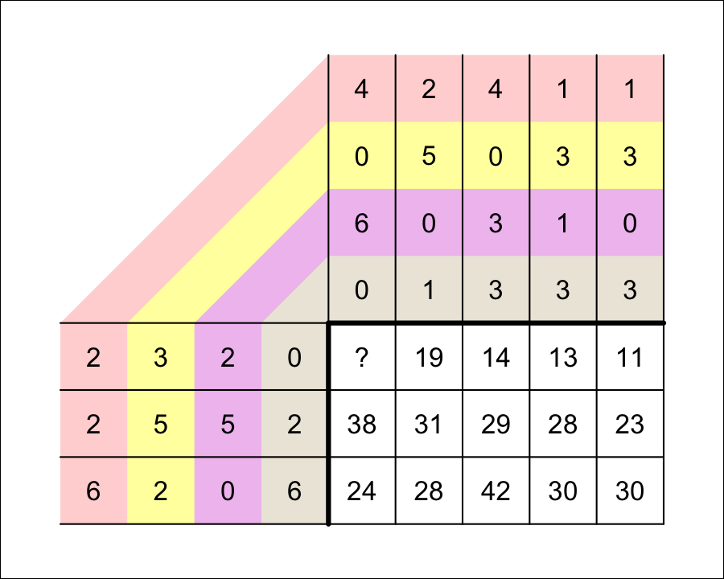

What is $c_{1,1}$?

To find $c_{1,1}$, you use row 1 from matrix $A$ and column 1 from matrix $B$.

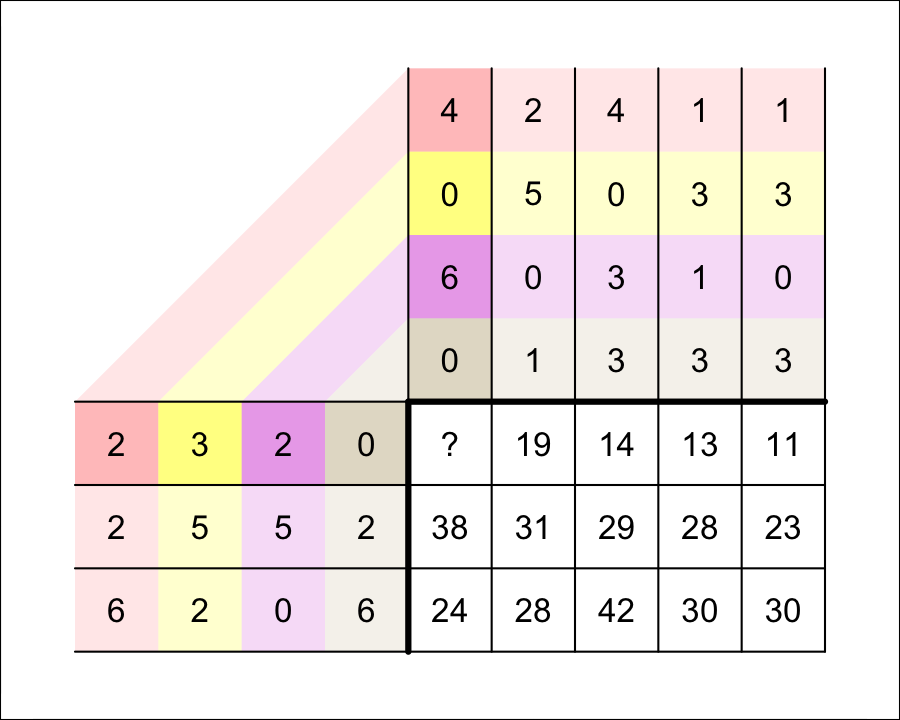

You multiply corresponding elements and sum those products.

$$c_{1,1}~=~( 2 \cdot 4 )+( 3 \cdot 0
)+( 2 \cdot 6 )+( 0 \cdot 0 )$$

$$c_{1,1}~=~8+0+12+0$$

$$c_{1,1}~=~20$$

Thus,

$$\begin{bmatrix}
2 & 3 & 2 & 0\\
2 & 5 & 5 & 2\\
6 & 2 & 0 & 6
\end{bmatrix} \cdot \begin{bmatrix}
4 & 2 & 4 & 1 & 1\\
0 & 5 & 0 & 3 & 3\\
6 & 0 & 3 & 1 & 0\\
0 & 1 & 3 & 3 & 3
\end{bmatrix} ~=~ \begin{bmatrix}
20 & 19 & 14 & 13 & 11\\
38 & 31 & 29 & 28 & 23\\
24 & 28 & 42 & 30 & 30
\end{bmatrix}$$

Let matrices $A$ and $B$ be defined below.

$$A = \begin{bmatrix}
2 & 3 & 2 & 1\\
6 & 4 & 5 & 3\\
6 & 0 & 0 & 1
\end{bmatrix}$$
$$B = \begin{bmatrix}
1 & 6 & 3 & 1 & 2\\
1 & 0 & 0 & 1 & 3\\
3 & 5 & 2 & 5 & 4\\
5 & 5 & 3 & 3 & 4
\end{bmatrix}$$

A third matrix, $C$, is equal to the [product](https://en.wikipedia.org/wiki/Matrix_multiplication) $AB$. A student set up a diagram to help find the product; they are missing a single element in $C$, element $c_{1,3}$.

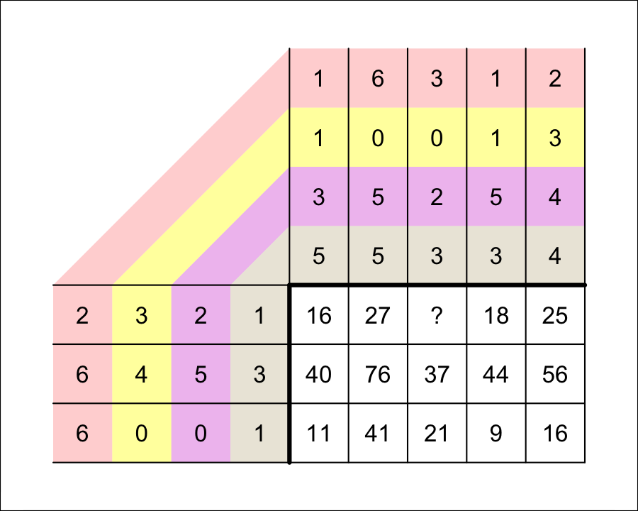

What is $c_{1,3}$?

To find $c_{1,3}$, you use row 1 from matrix $A$ and column 3 from matrix $B$.

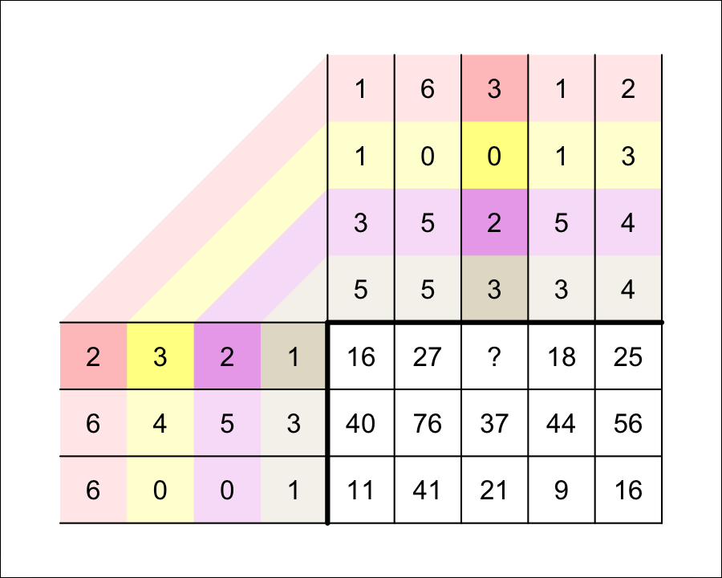

You multiply corresponding elements and sum those products.

$$c_{1,3}~=~( 2 \cdot 3 )+( 3 \cdot 0
)+( 2 \cdot 2 )+( 1 \cdot 3 )$$

$$c_{1,3}~=~6+0+4+3$$

$$c_{1,3}~=~13$$

Thus,

$$\begin{bmatrix}
2 & 3 & 2 & 1\\
6 & 4 & 5 & 3\\
6 & 0 & 0 & 1
\end{bmatrix} \cdot \begin{bmatrix}
1 & 6 & 3 & 1 & 2\\
1 & 0 & 0 & 1 & 3\\
3 & 5 & 2 & 5 & 4\\
5 & 5 & 3 & 3 & 4
\end{bmatrix} ~=~ \begin{bmatrix}
16 & 27 & 13 & 18 & 25\\
40 & 76 & 37 & 44 & 56\\
11 & 41 & 21 & 9 & 16
\end{bmatrix}$$

Let matrices $A$ and $B$ be defined below.

$$A = \begin{bmatrix}
4 & 1 & 1 & 5\\
6 & 3 & 6 & 0\\
6 & 2 & 3 & 2
\end{bmatrix}$$
$$B = \begin{bmatrix}
5 & 4 & 4 & 4 & 3\\
6 & 2 & 4 & 0 & 2\\
1 & 5 & 2 & 4 & 2\\
4 & 4 & 1 & 6 & 2
\end{bmatrix}$$

A third matrix, $C$, is equal to the [product](https://en.wikipedia.org/wiki/Matrix_multiplication) $AB$. A student set up a diagram to help find the product; they are missing a single element in $C$, element $c_{3,4}$.

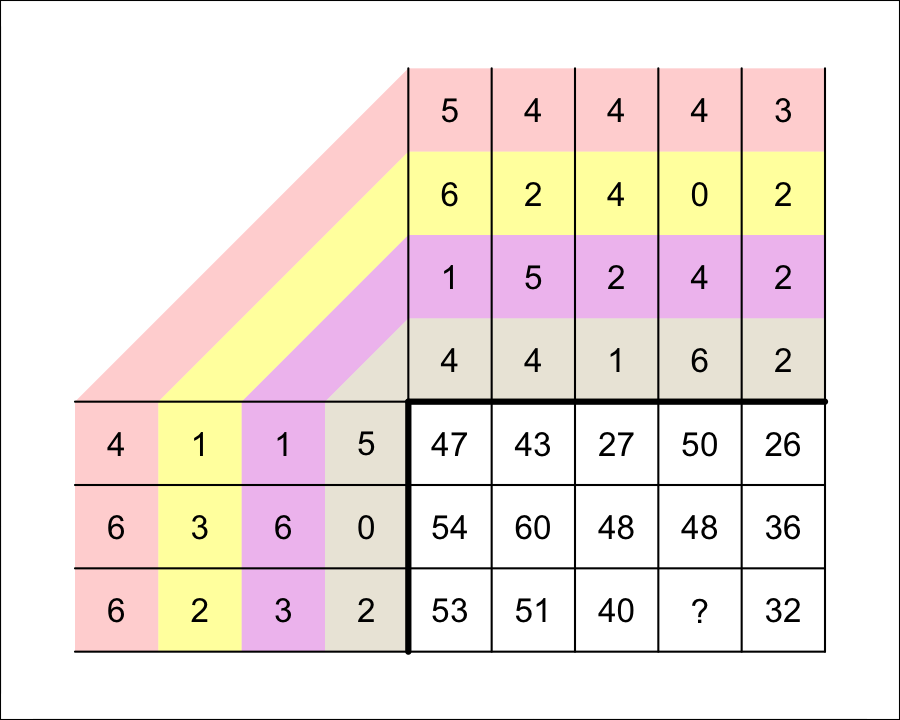

What is $c_{3,4}$?

To find $c_{3,4}$, you use row 3 from matrix $A$ and column 4 from matrix $B$.

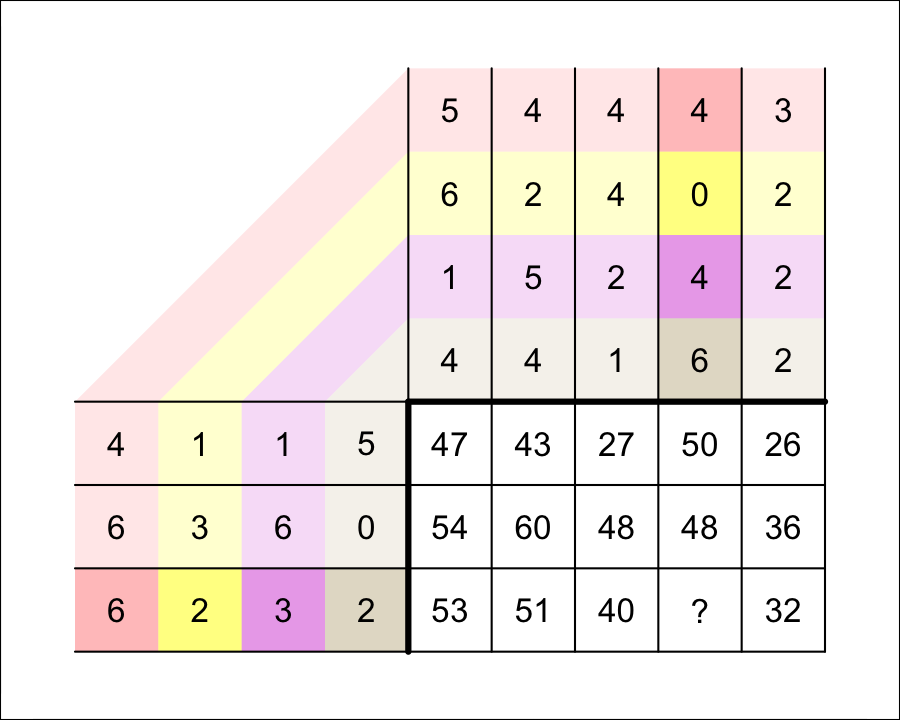

You multiply corresponding elements and sum those products.

$$c_{3,4}~=~( 6 \cdot 4 )+( 2 \cdot 0
)+( 3 \cdot 4 )+( 2 \cdot 6 )$$

$$c_{3,4}~=~24+0+12+12$$

$$c_{3,4}~=~48$$

Thus,

$$\begin{bmatrix}
4 & 1 & 1 & 5\\
6 & 3 & 6 & 0\\
6 & 2 & 3 & 2
\end{bmatrix} \cdot \begin{bmatrix}
5 & 4 & 4 & 4 & 3\\
6 & 2 & 4 & 0 & 2\\
1 & 5 & 2 & 4 & 2\\
4 & 4 & 1 & 6 & 2
\end{bmatrix} ~=~ \begin{bmatrix}
47 & 43 & 27 & 50 & 26\\
54 & 60 & 48 & 48 & 36\\
53 & 51 & 40 & 48 & 32
\end{bmatrix}$$

Let matrices $A$ and $B$ be defined below.

$$A = \begin{bmatrix}
3 & 0 & 3 & 4\\
6 & 5 & 4 & 6\\
3 & 6 & 1 & 4
\end{bmatrix}$$
$$B = \begin{bmatrix}
6 & 4 & 6 & 0 & 6\\
2 & 4 & 3 & 2 & 2\\
4 & 1 & 1 & 1 & 5\\
2 & 3 & 3 & 4 & 0
\end{bmatrix}$$

A third matrix, $C$, is equal to the [product](https://en.wikipedia.org/wiki/Matrix_multiplication) $AB$. A student set up a diagram to help find the product; they are missing a single element in $C$, element $c_{3,3}$.

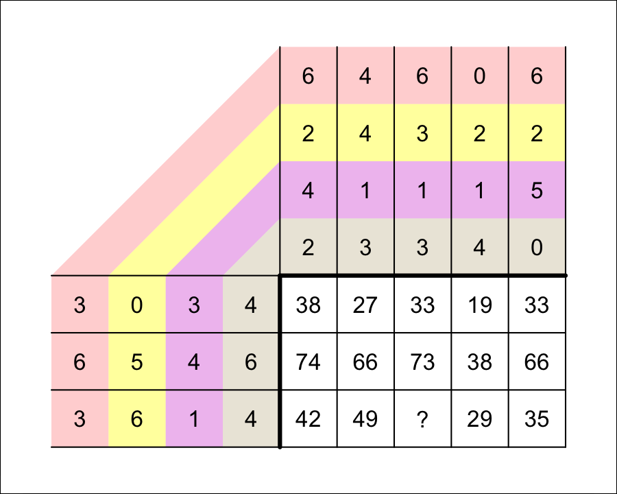

What is $c_{3,3}$?

To find $c_{3,3}$, you use row 3 from matrix $A$ and column 3 from matrix $B$.

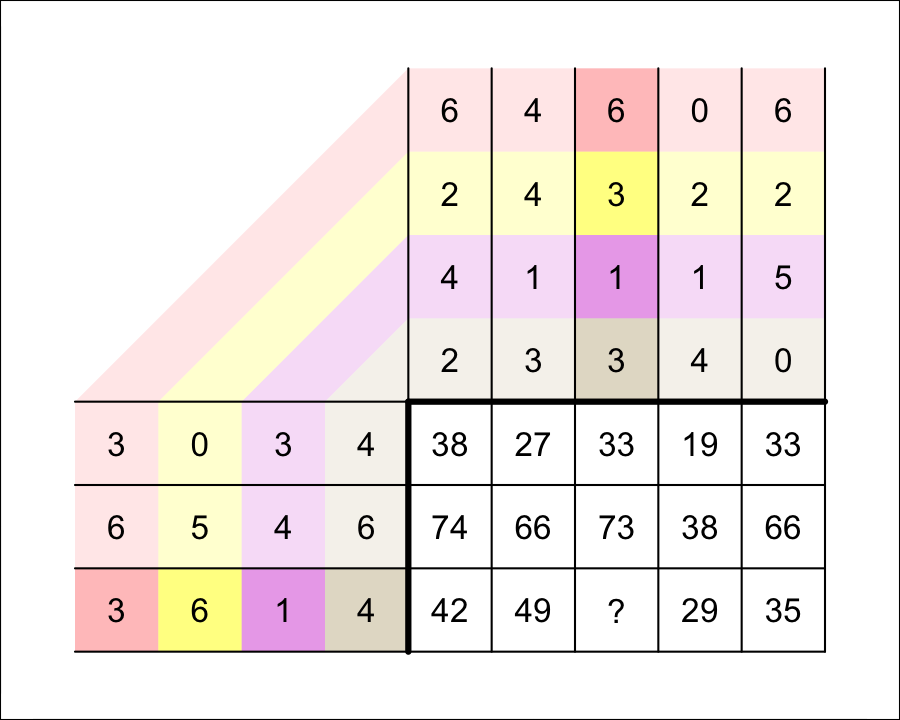

You multiply corresponding elements and sum those products.

$$c_{3,3}~=~( 3 \cdot 6 )+( 6 \cdot 3
)+( 1 \cdot 1 )+( 4 \cdot 3 )$$

$$c_{3,3}~=~18+18+1+12$$

$$c_{3,3}~=~49$$

Thus,

$$\begin{bmatrix}
3 & 0 & 3 & 4\\
6 & 5 & 4 & 6\\
3 & 6 & 1 & 4
\end{bmatrix} \cdot \begin{bmatrix}
6 & 4 & 6 & 0 & 6\\
2 & 4 & 3 & 2 & 2\\
4 & 1 & 1 & 1 & 5\\
2 & 3 & 3 & 4 & 0
\end{bmatrix} ~=~ \begin{bmatrix}
38 & 27 & 33 & 19 & 33\\
74 & 66 & 73 & 38 & 66\\
42 & 49 & 49 & 29 & 35
\end{bmatrix}$$

Let matrices $A$ and $B$ be defined below.

$$A = \begin{bmatrix}
0 & 5 & 5 & 5\\
1 & 3 & 0 & 5\\
5 & 1 & 0 & 2
\end{bmatrix}$$
$$B = \begin{bmatrix}
2 & 2 & 0 & 1 & 1\\
4 & 5 & 4 & 2 & 4\\
2 & 0 & 0 & 1 & 4\\
2 & 1 & 2 & 2 & 5
\end{bmatrix}$$

A third matrix, $C$, is equal to the [product](https://en.wikipedia.org/wiki/Matrix_multiplication) $AB$. A student set up a diagram to help find the product; they are missing a single element in $C$, element $c_{3,5}$.

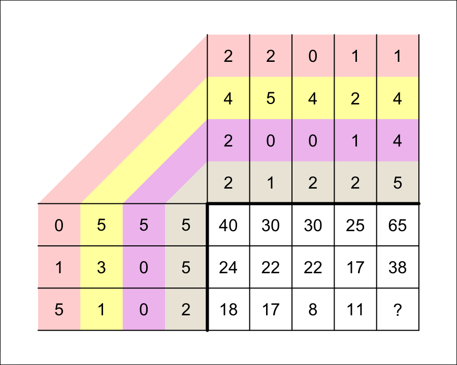

What is $c_{3,5}$?

To find $c_{3,5}$, you use row 3 from matrix $A$ and column 5 from matrix $B$.

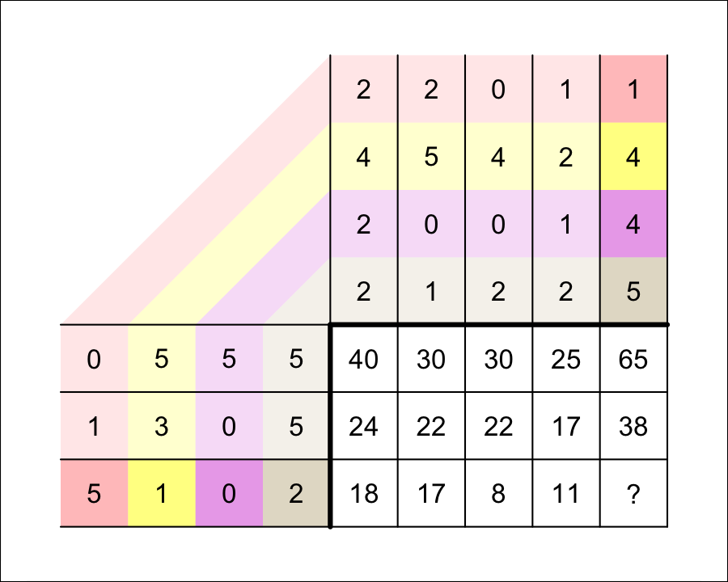

You multiply corresponding elements and sum those products.

$$c_{3,5}~=~( 5 \cdot 1 )+( 1 \cdot 4
)+( 0 \cdot 4 )+( 2 \cdot 5 )$$

$$c_{3,5}~=~5+4+0+10$$

$$c_{3,5}~=~19$$

Thus,

$$\begin{bmatrix}
0 & 5 & 5 & 5\\
1 & 3 & 0 & 5\\
5 & 1 & 0 & 2
\end{bmatrix} \cdot \begin{bmatrix}
2 & 2 & 0 & 1 & 1\\
4 & 5 & 4 & 2 & 4\\
2 & 0 & 0 & 1 & 4\\
2 & 1 & 2 & 2 & 5
\end{bmatrix} ~=~ \begin{bmatrix}
40 & 30 & 30 & 25 & 65\\
24 & 22 & 22 & 17 & 38\\
18 & 17 & 8 & 11 & 19
\end{bmatrix}$$

Let matrices $A$ and $B$ be defined below.

$$A = \begin{bmatrix}
2 & 2 & 0 & 6\\
1 & 6 & 6 & 6\\
5 & 5 & 4 & 6
\end{bmatrix}$$
$$B = \begin{bmatrix}
3 & 2 & 5 & 2 & 6\\
0 & 1 & 0 & 1 & 0\\
4 & 6 & 1 & 5 & 1\\
2 & 0 & 6 & 6 & 5
\end{bmatrix}$$

A third matrix, $C$, is equal to the [product](https://en.wikipedia.org/wiki/Matrix_multiplication) $AB$. A student set up a diagram to help find the product; they are missing a single element in $C$, element $c_{1,4}$.

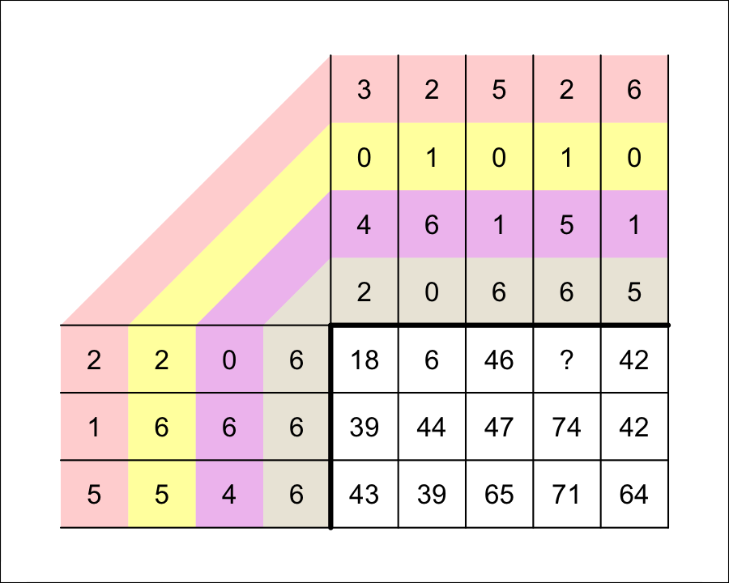

What is $c_{1,4}$?

To find $c_{1,4}$, you use row 1 from matrix $A$ and column 4 from matrix $B$.

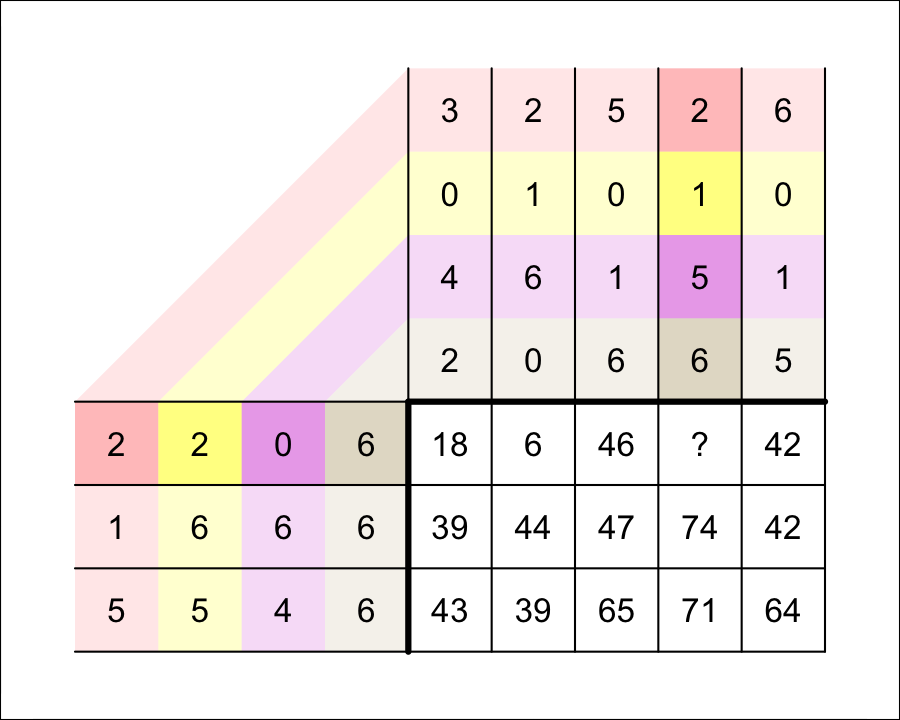

You multiply corresponding elements and sum those products.

$$c_{1,4}~=~( 2 \cdot 2 )+( 2 \cdot 1
)+( 0 \cdot 5 )+( 6 \cdot 6 )$$

$$c_{1,4}~=~4+2+0+36$$

$$c_{1,4}~=~42$$

Thus,

$$\begin{bmatrix}
2 & 2 & 0 & 6\\
1 & 6 & 6 & 6\\
5 & 5 & 4 & 6
\end{bmatrix} \cdot \begin{bmatrix}
3 & 2 & 5 & 2 & 6\\
0 & 1 & 0 & 1 & 0\\
4 & 6 & 1 & 5 & 1\\
2 & 0 & 6 & 6 & 5
\end{bmatrix} ~=~ \begin{bmatrix}
18 & 6 & 46 & 42 & 42\\
39 & 44 & 47 & 74 & 42\\
43 & 39 & 65 & 71 & 64
\end{bmatrix}$$

Let matrices $A$ and $B$ be defined below.

$$A = \begin{bmatrix}
6 & 2 & 4 & 4\\
0 & 3 & 4 & 0\\
0 & 5 & 6 & 5
\end{bmatrix}$$
$$B = \begin{bmatrix}
2 & 1 & 1 & 2 & 4\\
1 & 1 & 1 & 1 & 6\\
3 & 3 & 4 & 5 & 0\\
1 & 6 & 4 & 6 & 3
\end{bmatrix}$$

A third matrix, $C$, is equal to the [product](https://en.wikipedia.org/wiki/Matrix_multiplication) $AB$. A student set up a diagram to help find the product; they are missing a single element in $C$, element $c_{2,4}$.

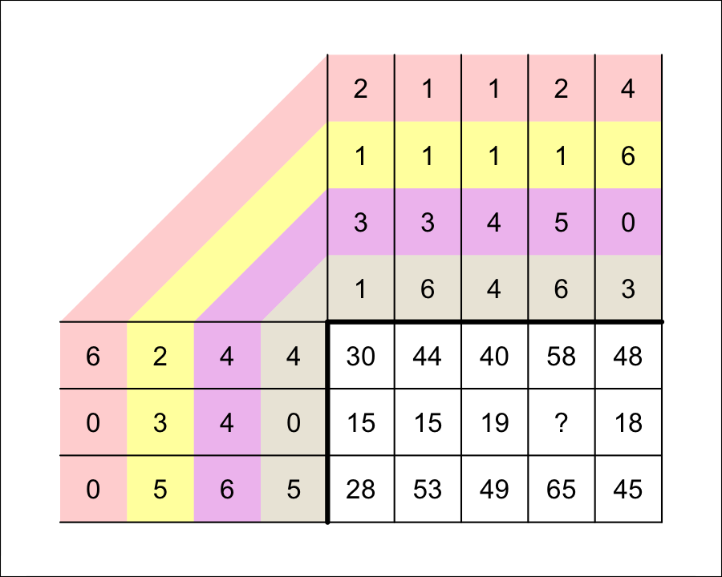

What is $c_{2,4}$?

To find $c_{2,4}$, you use row 2 from matrix $A$ and column 4 from matrix $B$.

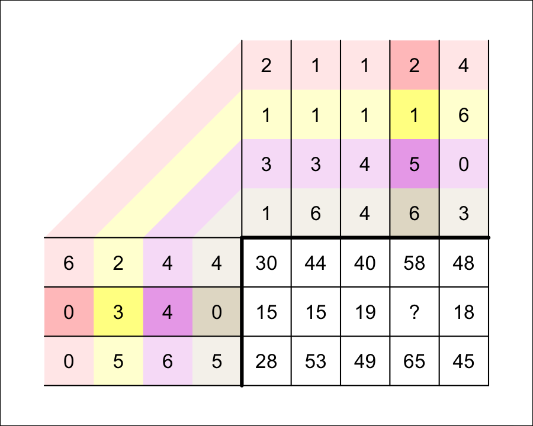

You multiply corresponding elements and sum those products.

$$c_{2,4}~=~( 0 \cdot 2 )+( 3 \cdot 1
)+( 4 \cdot 5 )+( 0 \cdot 6 )$$

$$c_{2,4}~=~0+3+20+0$$

$$c_{2,4}~=~23$$

Thus,

$$\begin{bmatrix}
6 & 2 & 4 & 4\\
0 & 3 & 4 & 0\\
0 & 5 & 6 & 5
\end{bmatrix} \cdot \begin{bmatrix}
2 & 1 & 1 & 2 & 4\\
1 & 1 & 1 & 1 & 6\\
3 & 3 & 4 & 5 & 0\\
1 & 6 & 4 & 6 & 3
\end{bmatrix} ~=~ \begin{bmatrix}
30 & 44 & 40 & 58 & 48\\
15 & 15 & 19 & 23 & 18\\
28 & 53 & 49 & 65 & 45
\end{bmatrix}$$

Let matrices $A$ and $B$ be defined below.

$$A = \begin{bmatrix}
4 & 2 & 4 & 4\\
1 & 3 & 5 & 1\\
6 & 0 & 5 & 0
\end{bmatrix}$$
$$B = \begin{bmatrix}
2 & 2 & 3 & 3 & 1\\
1 & 5 & 0 & 2 & 2\\
2 & 2 & 4 & 0 & 4\\
6 & 2 & 2 & 6 & 5
\end{bmatrix}$$

A third matrix, $C$, is equal to the [product](https://en.wikipedia.org/wiki/Matrix_multiplication) $AB$. A student set up a diagram to help find the product; they are missing a single element in $C$, element $c_{2,4}$.

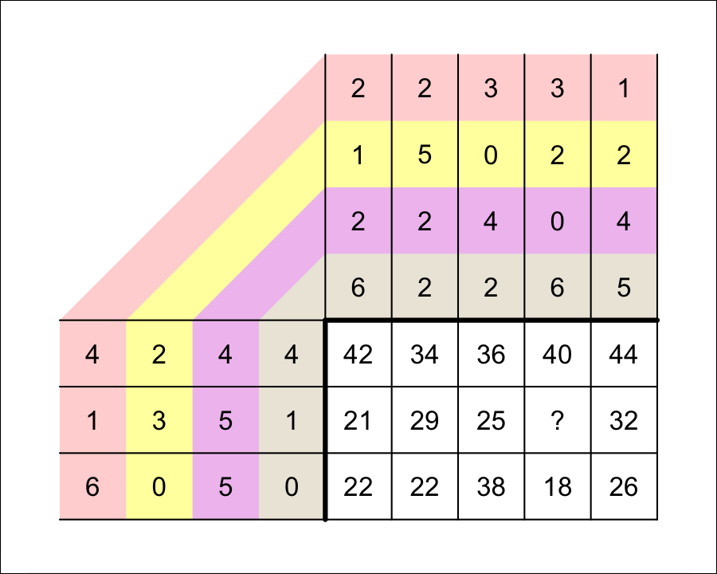

What is $c_{2,4}$?

To find $c_{2,4}$, you use row 2 from matrix $A$ and column 4 from matrix $B$.

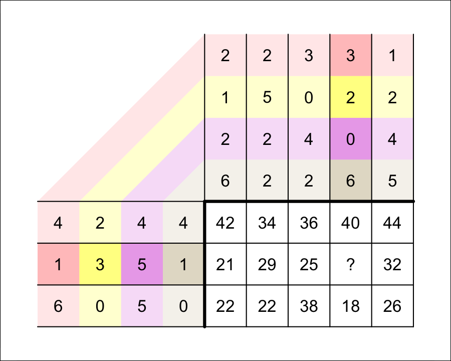

You multiply corresponding elements and sum those products.

$$c_{2,4}~=~( 1 \cdot 3 )+( 3 \cdot 2
)+( 5 \cdot 0 )+( 1 \cdot 6 )$$

$$c_{2,4}~=~3+6+0+6$$

$$c_{2,4}~=~15$$

Thus,

$$\begin{bmatrix}
4 & 2 & 4 & 4\\
1 & 3 & 5 & 1\\
6 & 0 & 5 & 0
\end{bmatrix} \cdot \begin{bmatrix}
2 & 2 & 3 & 3 & 1\\
1 & 5 & 0 & 2 & 2\\
2 & 2 & 4 & 0 & 4\\
6 & 2 & 2 & 6 & 5
\end{bmatrix} ~=~ \begin{bmatrix}
42 & 34 & 36 & 40 & 44\\
21 & 29 & 25 & 15 & 32\\
22 & 22 & 38 & 18 & 26
\end{bmatrix}$$

Let matrices $A$ and $B$ be defined below.

$$A = \begin{bmatrix}
2 & 3 & 0 & 6\\
1 & 1 & 3 & 5\\
4 & 3 & 4 & 0
\end{bmatrix}$$
$$B = \begin{bmatrix}
5 & 2 & 6 & 3 & 2\\
6 & 6 & 5 & 2 & 3\\
0 & 5 & 4 & 3 & 0\\
1 & 3 & 0 & 4 & 5
\end{bmatrix}$$

A third matrix, $C$, is equal to the [product](https://en.wikipedia.org/wiki/Matrix_multiplication) $AB$. A student set up a diagram to help find the product; they are missing a single element in $C$, element $c_{2,5}$.

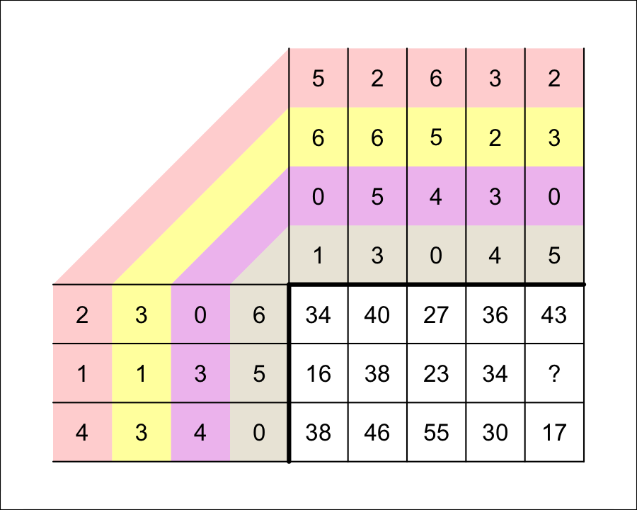

What is $c_{2,5}$?

To find $c_{2,5}$, you use row 2 from matrix $A$ and column 5 from matrix $B$.

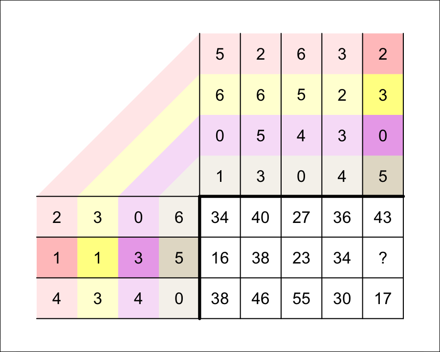

You multiply corresponding elements and sum those products.

$$c_{2,5}~=~( 1 \cdot 2 )+( 1 \cdot 3
)+( 3 \cdot 0 )+( 5 \cdot 5 )$$

$$c_{2,5}~=~2+3+0+25$$

$$c_{2,5}~=~30$$

Thus,

$$\begin{bmatrix}
2 & 3 & 0 & 6\\
1 & 1 & 3 & 5\\
4 & 3 & 4 & 0
\end{bmatrix} \cdot \begin{bmatrix}
5 & 2 & 6 & 3 & 2\\
6 & 6 & 5 & 2 & 3\\
0 & 5 & 4 & 3 & 0\\
1 & 3 & 0 & 4 & 5
\end{bmatrix} ~=~ \begin{bmatrix}
34 & 40 & 27 & 36 & 43\\
16 & 38 & 23 & 34 & 30\\
38 & 46 & 55 & 30 & 17
\end{bmatrix}$$

Let matrices $A$ and $B$ be defined below.

$$A = \begin{bmatrix}
0 & 5 & 3 & 3\\
2 & 0 & 5 & 4\\
6 & 1 & 3 & 6
\end{bmatrix}$$
$$B = \begin{bmatrix}
4 & 4 & 6 & 4 & 0\\
1 & 4 & 5 & 5 & 0\\
2 & 6 & 1 & 4 & 4\\
5 & 2 & 1 & 5 & 0
\end{bmatrix}$$

A third matrix, $C$, is equal to the [product](https://en.wikipedia.org/wiki/Matrix_multiplication) $AB$. A student set up a diagram to help find the product; they are missing a single element in $C$, element $c_{2,1}$.

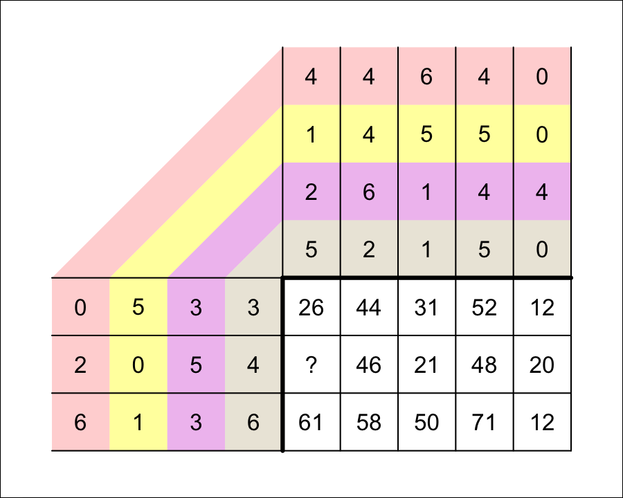

What is $c_{2,1}$?

To find $c_{2,1}$, you use row 2 from matrix $A$ and column 1 from matrix $B$.

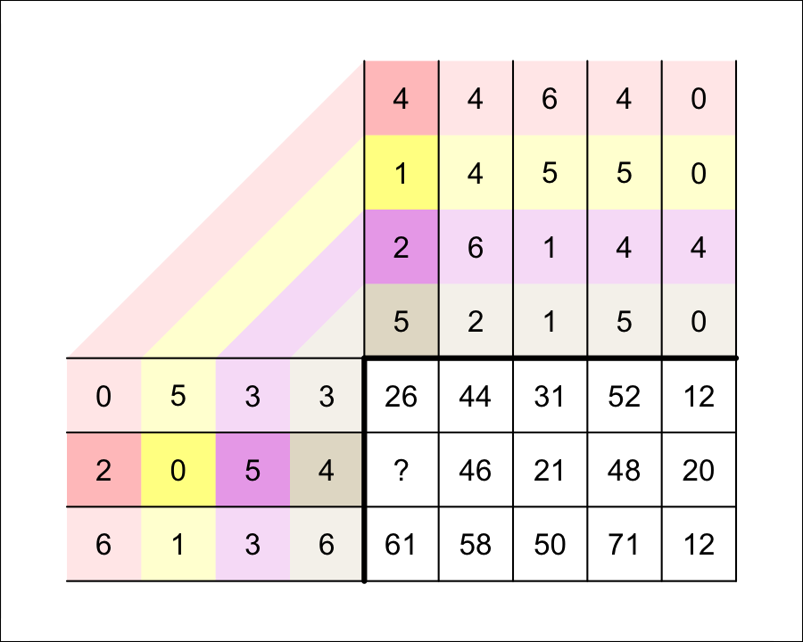

You multiply corresponding elements and sum those products.

$$c_{2,1}~=~( 2 \cdot 4 )+( 0 \cdot 1
)+( 5 \cdot 2 )+( 4 \cdot 5 )$$

$$c_{2,1}~=~8+0+10+20$$

$$c_{2,1}~=~38$$

Thus,

$$\begin{bmatrix}
0 & 5 & 3 & 3\\
2 & 0 & 5 & 4\\
6 & 1 & 3 & 6
\end{bmatrix} \cdot \begin{bmatrix}
4 & 4 & 6 & 4 & 0\\
1 & 4 & 5 & 5 & 0\\
2 & 6 & 1 & 4 & 4\\
5 & 2 & 1 & 5 & 0
\end{bmatrix} ~=~ \begin{bmatrix}
26 & 44 & 31 & 52 & 12\\
38 & 46 & 21 & 48 & 20\\
61 & 58 & 50 & 71 & 12
\end{bmatrix}$$

Let matrices $A$ and $B$ be defined below.

$$A = \begin{bmatrix}
6 & 4 & 3 & 0\\
3 & 3 & 5 & 2\\
2 & 3 & 2 & 1
\end{bmatrix}$$
$$B = \begin{bmatrix}
1 & 6 & 4 & 4 & 6\\
6 & 3 & 6 & 0 & 0\\
1 & 1 & 6 & 0 & 6\\
1 & 4 & 5 & 3 & 0
\end{bmatrix}$$

A third matrix, $C$, is equal to the [product](https://en.wikipedia.org/wiki/Matrix_multiplication) $AB$. A student set up a diagram to help find the product; they are missing a single element in $C$, element $c_{1,4}$.

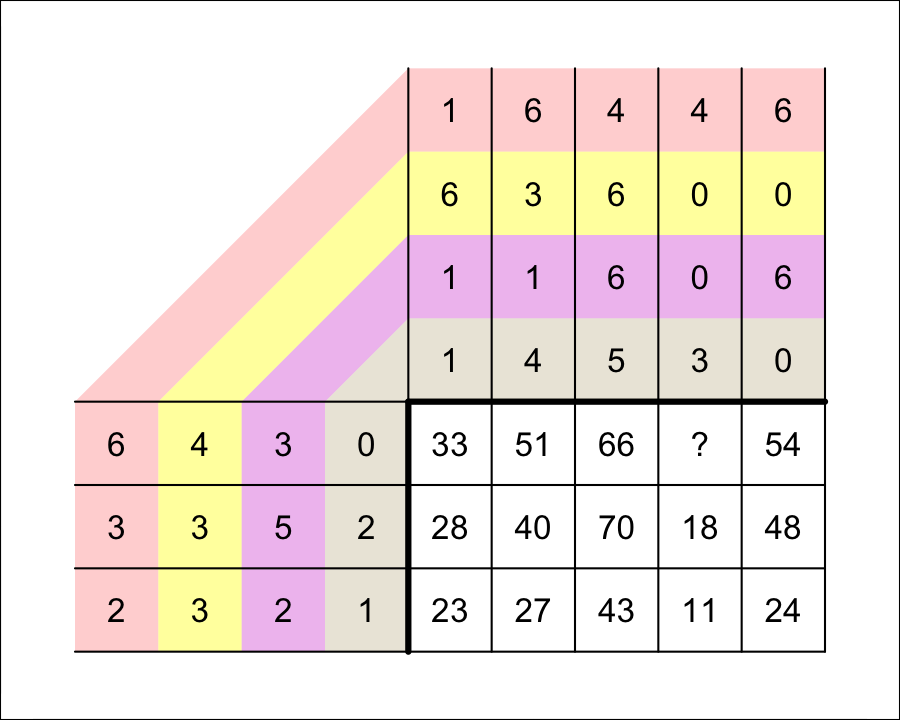

What is $c_{1,4}$?

To find $c_{1,4}$, you use row 1 from matrix $A$ and column 4 from matrix $B$.

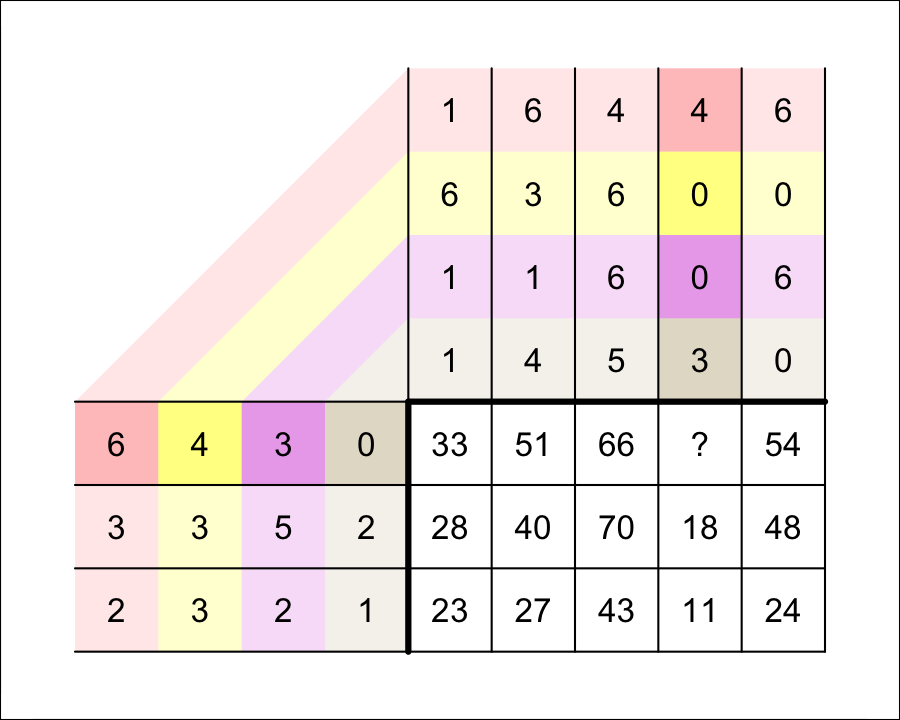

You multiply corresponding elements and sum those products.

$$c_{1,4}~=~( 6 \cdot 4 )+( 4 \cdot 0
)+( 3 \cdot 0 )+( 0 \cdot 3 )$$

$$c_{1,4}~=~24+0+0+0$$

$$c_{1,4}~=~24$$

Thus,

$$\begin{bmatrix}
6 & 4 & 3 & 0\\
3 & 3 & 5 & 2\\
2 & 3 & 2 & 1
\end{bmatrix} \cdot \begin{bmatrix}
1 & 6 & 4 & 4 & 6\\
6 & 3 & 6 & 0 & 0\\
1 & 1 & 6 & 0 & 6\\
1 & 4 & 5 & 3 & 0
\end{bmatrix} ~=~ \begin{bmatrix}
33 & 51 & 66 & 24 & 54\\
28 & 40 & 70 & 18 & 48\\
23 & 27 & 43 & 11 & 24
\end{bmatrix}$$

Let matrices $A$ and $B$ be defined below.

$$A = \begin{bmatrix}
3 & 2 & 5 & 0\\
3 & 6 & 1 & 5\\
6 & 3 & 0 & 0
\end{bmatrix}$$
$$B = \begin{bmatrix}
0 & 0 & 1 & 1 & 4\\
5 & 5 & 5 & 3 & 4\\
6 & 5 & 0 & 1 & 6\\
3 & 5 & 5 & 5 & 5
\end{bmatrix}$$

A third matrix, $C$, is equal to the [product](https://en.wikipedia.org/wiki/Matrix_multiplication) $AB$. A student set up a diagram to help find the product; they are missing a single element in $C$, element $c_{1,1}$.

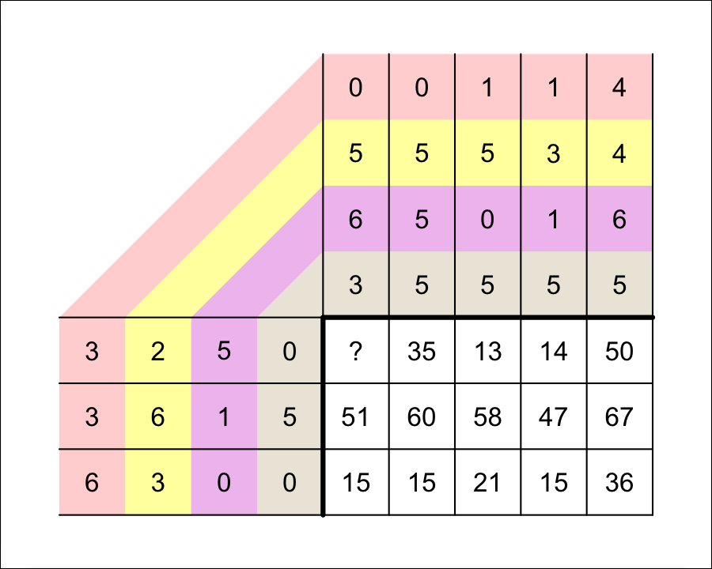

What is $c_{1,1}$?

To find $c_{1,1}$, you use row 1 from matrix $A$ and column 1 from matrix $B$.

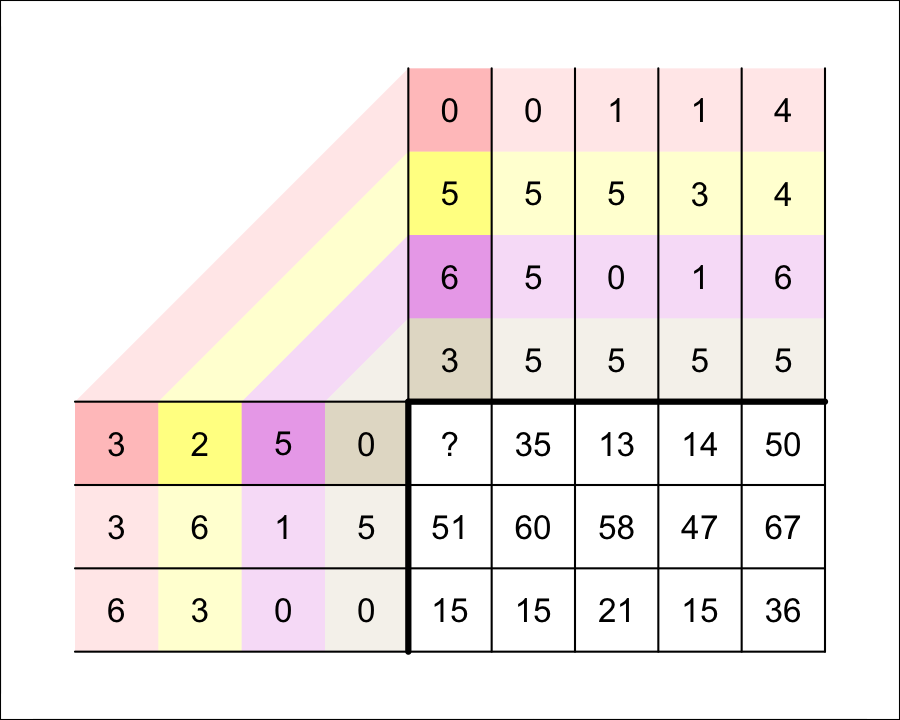

You multiply corresponding elements and sum those products.

$$c_{1,1}~=~( 3 \cdot 0 )+( 2 \cdot 5
)+( 5 \cdot 6 )+( 0 \cdot 3 )$$

$$c_{1,1}~=~0+10+30+0$$

$$c_{1,1}~=~40$$

Thus,

$$\begin{bmatrix}
3 & 2 & 5 & 0\\
3 & 6 & 1 & 5\\
6 & 3 & 0 & 0
\end{bmatrix} \cdot \begin{bmatrix}
0 & 0 & 1 & 1 & 4\\
5 & 5 & 5 & 3 & 4\\
6 & 5 & 0 & 1 & 6\\
3 & 5 & 5 & 5 & 5
\end{bmatrix} ~=~ \begin{bmatrix}
40 & 35 & 13 & 14 & 50\\
51 & 60 & 58 & 47 & 67\\
15 & 15 & 21 & 15 & 36
\end{bmatrix}$$

Let matrices $A$ and $B$ be defined below.

$$A = \begin{bmatrix}
0 & 3 & 2 & 1\\
5 & 2 & 0 & 4\\
0 & 3 & 5 & 6
\end{bmatrix}$$
$$B = \begin{bmatrix}
4 & 6 & 0 & 4 & 4\\
4 & 1 & 0 & 6 & 5\\
4 & 3 & 6 & 6 & 0\\
2 & 4 & 4 & 2 & 2
\end{bmatrix}$$

A third matrix, $C$, is equal to the [product](https://en.wikipedia.org/wiki/Matrix_multiplication) $AB$. A student set up a diagram to help find the product; they are missing a single element in $C$, element $c_{1,2}$.

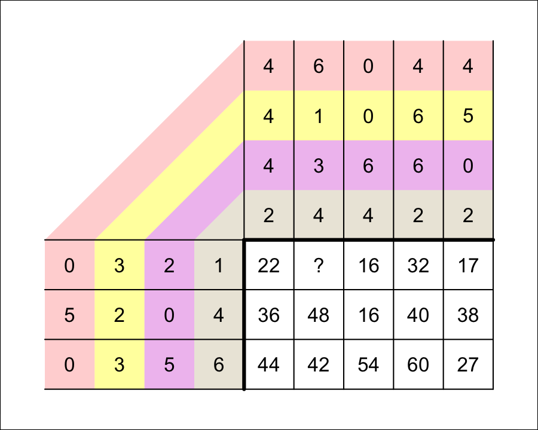

What is $c_{1,2}$?

To find $c_{1,2}$, you use row 1 from matrix $A$ and column 2 from matrix $B$.

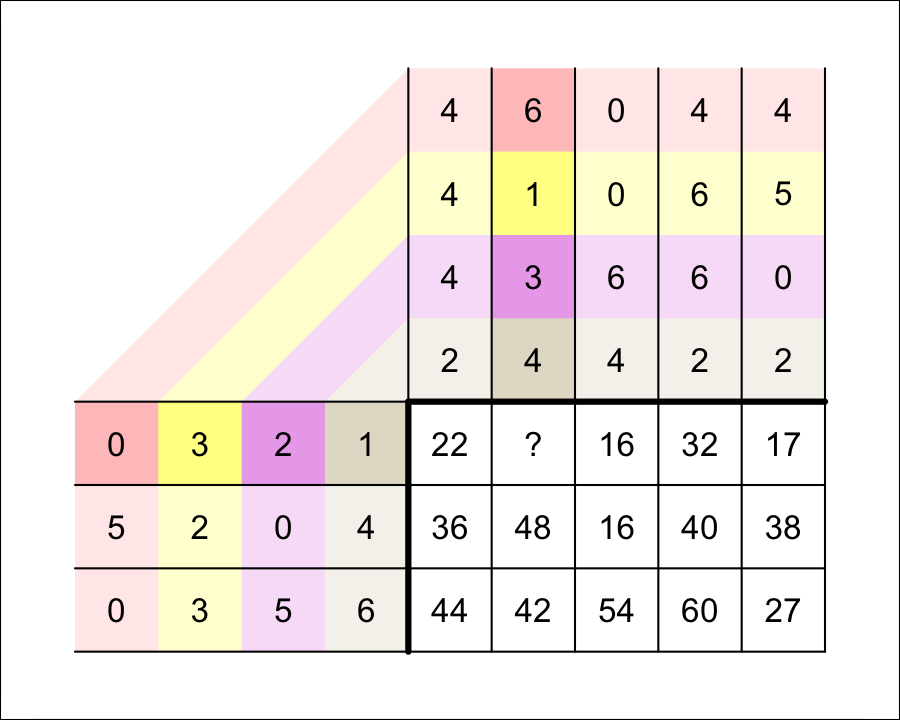

You multiply corresponding elements and sum those products.

$$c_{1,2}~=~( 0 \cdot 6 )+( 3 \cdot 1
)+( 2 \cdot 3 )+( 1 \cdot 4 )$$

$$c_{1,2}~=~0+3+6+4$$

$$c_{1,2}~=~13$$

Thus,

$$\begin{bmatrix}
0 & 3 & 2 & 1\\
5 & 2 & 0 & 4\\
0 & 3 & 5 & 6
\end{bmatrix} \cdot \begin{bmatrix}
4 & 6 & 0 & 4 & 4\\
4 & 1 & 0 & 6 & 5\\
4 & 3 & 6 & 6 & 0\\
2 & 4 & 4 & 2 & 2
\end{bmatrix} ~=~ \begin{bmatrix}
22 & 13 & 16 & 32 & 17\\
36 & 48 & 16 & 40 & 38\\
44 & 42 & 54 & 60 & 27
\end{bmatrix}$$

Let matrices $A$ and $B$ be defined below.

$$A = \begin{bmatrix}
1 & 2 & 1 & 1\\
4 & 2 & 5 & 3\\
6 & 5 & 1 & 0
\end{bmatrix}$$
$$B = \begin{bmatrix}
0 & 0 & 4 & 2 & 6\\
6 & 6 & 1 & 3 & 1\\
0 & 1 & 3 & 1 & 5\\
1 & 0 & 0 & 6 & 4
\end{bmatrix}$$

A third matrix, $C$, is equal to the [product](https://en.wikipedia.org/wiki/Matrix_multiplication) $AB$. A student set up a diagram to help find the product; they are missing a single element in $C$, element $c_{2,2}$.

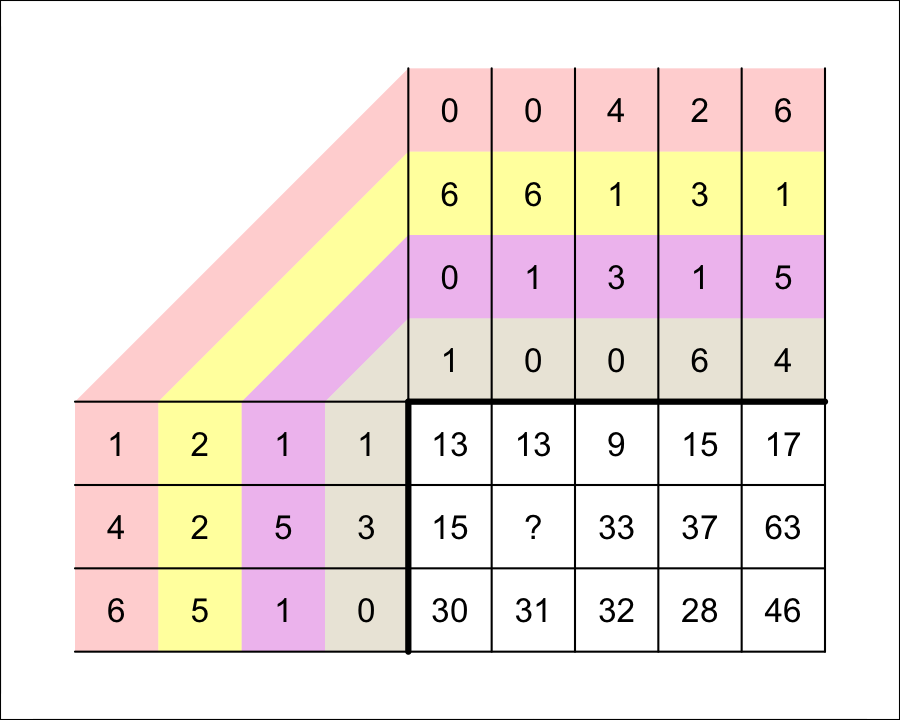

What is $c_{2,2}$?

To find $c_{2,2}$, you use row 2 from matrix $A$ and column 2 from matrix $B$.

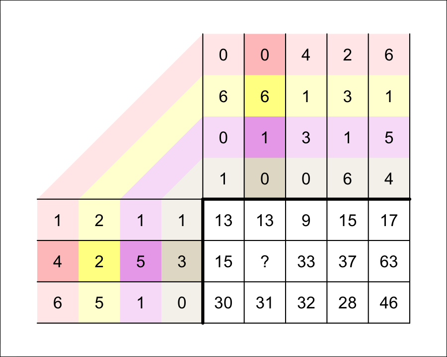

You multiply corresponding elements and sum those products.

$$c_{2,2}~=~( 4 \cdot 0 )+( 2 \cdot 6
)+( 5 \cdot 1 )+( 3 \cdot 0 )$$

$$c_{2,2}~=~0+12+5+0$$

$$c_{2,2}~=~17$$

Thus,

$$\begin{bmatrix}
1 & 2 & 1 & 1\\
4 & 2 & 5 & 3\\
6 & 5 & 1 & 0
\end{bmatrix} \cdot \begin{bmatrix}
0 & 0 & 4 & 2 & 6\\
6 & 6 & 1 & 3 & 1\\
0 & 1 & 3 & 1 & 5\\
1 & 0 & 0 & 6 & 4
\end{bmatrix} ~=~ \begin{bmatrix}
13 & 13 & 9 & 15 & 17\\
15 & 17 & 33 & 37 & 63\\
30 & 31 & 32 & 28 & 46
\end{bmatrix}$$

Let matrices $A$ and $B$ be defined below.

$$A = \begin{bmatrix}
5 & 1 & 3 & 5\\
4 & 3 & 6 & 1\\
1 & 0 & 6 & 2
\end{bmatrix}$$
$$B = \begin{bmatrix}
6 & 3 & 2 & 3 & 3\\
4 & 0 & 4 & 4 & 1\\
6 & 6 & 4 & 4 & 4\\
5 & 1 & 4 & 3 & 3
\end{bmatrix}$$